# Prédiction la consommation électrique horaire sur une semaine

Peter Martey Addo,PhD | Data Scientist, AFD-Agence Française de Développement

Data Challenge, JDS 2018

pkaddo2000@gmail.com

20 Avril 2018

Le **Data Challenge** organisé par le “groupe des Jeunes Statisticien.ne.s” est une compétition ouverte à tous visant à étudier des jeux de données mis à disposition par de grandes entreprises ou des entités publiques.

Le but de ce challenge est de prévoir la **consommation électrique** de l’île d’Ouessant à 8 jours, en s’aidant des données suivantes :

- un an de données de consommation historiques, à la **maille horaire** (*conso_train.csv*),
- un an de données météorologiques à la **maille tri-horaire**, issues de la proche station météorologique de Brest (*meteo_train.csv*),
- une semaine de données météorologiques à la **maille tri-horaire**, issues de la même station et faisant office de prédiction météorologique (*meteo_prev.csv*).

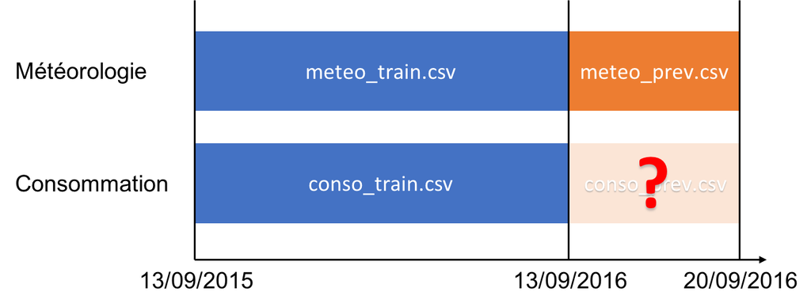

Source: https://www.sfds.asso.fr/fr/jeunes_statisticiens/manifestations/610-data_challenge/

# Introduction

This workflow is organised as follows: the loading packages, data preparation, importing data. Next, we provide some visualisations for insights as exploration phase. We prepare data for modeling and then present a summary of the predictive model. Finally, we obtain predictions and export output as required.

# Loading Packages, Reading and loading data

```r
# Load libraries
library(h2o)        # Awesome ML Library
library(timetk)     # Toolkit for working with time series in R
library(tidyquant)  # Loads tidyverse, financial pkgs, used to get data
library(keras)
library(lime)
library(rsample)
library(recipes)
library(yardstick)
library(corrr)
library(forcats)
library(highcharter)
library(janitor)
library(readr)

# Initialise H2o and java 8
Sys.setenv(JAVA_HOME="/Library/Java/JavaVirtualMachines/jdk1.8.0_152.jdk/Contents/Home")
suppressMessages(h2o.init(max_mem_size = "6g"))
h2o.no_progress()
```

```r
# Import data
library(readr)
conso_train <- read_delim("datasets/conso_train.csv", ";", escape_double = FALSE, trim_ws = TRUE)
meteo_train <- read_delim("datasets/meteo_train.csv", ";", escape_double = FALSE, trim_ws = TRUE)
meteo_prev <- read_delim("datasets/meteo_prev.csv", ";", escape_double = FALSE, trim_ws = TRUE)

dim(meteo_train)
```

```
## [1] 2928   12
```

```r
dim(meteo_prev)
```

```
## [1] 65 12
```

```r
dim(conso_train)
```

```
## [1] 8760    2
```

```r
glimpse(conso_train)
```

```
## Observations: 8,760
## Variables: 2
## $ date      <dttm> 2015-09-12 22:59:59, 2015-09-12 23:59:59, 2015-09-1...
## $ puissance <dbl> 526.1667, 495.0000, 446.1667, 365.8333, 341.0000, 35...
```

```r
summary(conso_train)
```

```
##       date                       puissance
##  Min.   :2015-09-12 22:59:59   Min.   : 294.2
##  1st Qu.:2015-12-13 05:44:59   1st Qu.: 527.0
##  Median :2016-03-14 11:30:00   Median : 719.2
##  Mean   :2016-03-13 23:48:34   Mean   : 752.6
##  3rd Qu.:2016-06-13 16:15:00   3rd Qu.: 950.2
##  Max.   :2016-09-12 22:00:00   Max.   :1732.2
```

# Data Prepare and Clean up

```r
## Prepare and Clean up data

# Clean Meteo train data
meteo_train_edited <- meteo_train %>%
  janitor::clean_names() %>%
  mutate(date_utc= dmy_hm(date_utc))
meteo_train_ts <- timetk::tk_xts(meteo_train_edited)

# Clean Meteo train data
meteo_prev_edited <- meteo_prev %>%
  janitor::clean_names() %>%
  mutate(date_utc= dmy_hm(date_utc))
meteo_prev_ts <- timetk::tk_xts(meteo_prev_edited)

# Clean Conso train data
conso_train_ts <- timetk::tk_xts(conso_train)
```

## Exploration

```r
## Plots Conso  Puissance

# Plot Conso Puissance
#hchart(conso_train_ts, name = "Puissance", color = "#B71C1C")
hc <- highchart(type = "stock") %>%
  hc_title(text = "Charting Puissance against time") %>%
  hc_subtitle(text = "Data on conso") %>%
  hc_add_series(conso_train_ts$puissance, name = "Puissance")
hc
```

[interactive chart not shown]

```r
# Plot all series => Conso & Meteo
hc <- highchart(type = "stock") %>%
  hc_title(text = "Charting some variables") %>%
  hc_subtitle(text = "Data from conso and meteo") %>%
  hc_add_series(meteo_train_ts$t_c, name = "t_c") %>%
  hc_add_series(meteo_train_ts$p_hpa, name = "p_hpa") %>%
  hc_add_series(meteo_train_ts$hr_percent, name = "hr_percent") %>%
  hc_add_series(meteo_train_ts$p_ros_e_c, name = "p_ros_e_c") %>%
  hc_add_series(meteo_train_ts$visi_km, name = "visi_km") %>%
  hc_add_series(meteo_train_ts$vt_moy_km_h, name = "vt_moy_km_h") %>%
  hc_add_series(meteo_train_ts$vt_raf_km_h, name = "vt_raf_km_h") %>%
  hc_add_series(meteo_train_ts$vt_dir, name = "vt_dir") %>%
  hc_add_series(meteo_train_ts$rr_3h_mm, name = "rr_3h_mm") %>%
  hc_add_series(meteo_train_ts$neige_cm, name = "neige_cm") %>%
  hc_add_series(meteo_train_ts$nebul_octats, name = "nebul_octats") %>%
  hc_add_series(conso_train_ts$puissance, name = "puissance")
hc
```

[interactive chart not shown]

## Augment Time Series signature

Augment Time Series signature and prepare conso train data

```r
########## Conso Train ###############
# Starting point
conso_train_ts_tbl <- conso_train  # %>%  glimpse()

# AUGMENT TIME SERIES SIGNATURE
# Augment time series signature (adds data frame columns)
conso_train_ts_tbl_aug <- conso_train_ts_tbl %>%
  tk_augment_timeseries_signature()

#conso_train_ts_tbl_aug %>% glimpse()

# Prep Conso Data
conso_train_ts_tbl_clean <- conso_train_ts_tbl_aug %>%
  mutate_if(is.factor, factor, ordered = FALSE) %>%
  select(-ends_with(".num"),-ends_with(".lbl"),-ends_with(".iso"))

conso_train_ts_tbl_clean %>% glimpse()
```

```
## Observations: 8,760
## Variables: 25
## $ date      <dttm> 2015-09-12 22:59:59, 2015-09-12 23:59:59, 2015-09-1...
## $ puissance <dbl> 526.1667, 495.0000, 446.1667, 365.8333, 341.0000, 35...
## $ diff      <int> NA, 3600, 3600, 3600, 3600, 3600, 3600, 3600, 3600, ...
## $ year      <int> 2015, 2015, 2015, 2015, 2015, 2015, 2015, 2015, 2015...
## $ half      <int> 2, 2, 2, 2, 2, 2, 2, 2, 2, 2, 2, 2, 2, 2, 2, 2, 2, 2...
## $ quarter   <int> 3, 3, 3, 3, 3, 3, 3, 3, 3, 3, 3, 3, 3, 3, 3, 3, 3, 3...
## $ month     <int> 9, 9, 9, 9, 9, 9, 9, 9, 9, 9, 9, 9, 9, 9, 9, 9, 9, 9...
## $ month.xts <int> 8, 8, 8, 8, 8, 8, 8, 8, 8, 8, 8, 8, 8, 8, 8, 8, 8, 8...
## $ day       <int> 12, 12, 13, 13, 13, 13, 13, 13, 13, 13, 13, 13, 13, ...
## $ hour      <int> 22, 23, 0, 1, 2, 3, 4, 5, 6, 7, 8, 9, 10, 11, 12, 13...
## $ minute    <int> 59, 59, 59, 59, 59, 59, 59, 59, 59, 59, 59, 59, 59, ...
## $ second    <int> 59, 59, 59, 59, 59, 59, 59, 59, 59, 59, 59, 59, 59, ...
## $ hour12    <int> 10, 11, 0, 1, 2, 3, 4, 5, 6, 7, 8, 9, 10, 11, 0, 1, ...
## $ am.pm     <int> 2, 2, 1, 1, 1, 1, 1, 1, 1, 1, 1, 1, 1, 1, 2, 2, 2, 2...
## $ wday      <int> 7, 7, 1, 1, 1, 1, 1, 1, 1, 1, 1, 1, 1, 1, 1, 1, 1, 1...
## $ wday.xts  <int> 6, 6, 0, 0, 0, 0, 0, 0, 0, 0, 0, 0, 0, 0, 0, 0, 0, 0...
## $ mday      <int> 12, 12, 13, 13, 13, 13, 13, 13, 13, 13, 13, 13, 13, ...
## $ qday      <int> 74, 74, 75, 75, 75, 75, 75, 75, 75, 75, 75, 75, 75, ...
## $ yday      <int> 255, 255, 256, 256, 256, 256, 256, 256, 256, 256, 25...
## $ mweek     <int> 2, 2, 3, 3, 3, 3, 3, 3, 3, 3, 3, 3, 3, 3, 3, 3, 3, 3...
## $ week      <int> 37, 37, 37, 37, 37, 37, 37, 37, 37, 37, 37, 37, 37, ...
## $ week2     <int> 1, 1, 1, 1, 1, 1, 1, 1, 1, 1, 1, 1, 1, 1, 1, 1, 1, 1...
## $ week3     <int> 1, 1, 1, 1, 1, 1, 1, 1, 1, 1, 1, 1, 1, 1, 1, 1, 1, 1...
## $ week4     <int> 1, 1, 1, 1, 1, 1, 1, 1, 1, 1, 1, 1, 1, 1, 1, 1, 1, 1...
## $ mday7     <int> 2, 2, 2, 2, 2, 2, 2, 2, 2, 2, 2, 2, 2, 2, 2, 2, 2, 2...
```

Augment Time Series signature and prepare meteo train & prevision data

```r
########## Meteo Train & Prev ###############
meteo_train_ts_tbl_clean <- meteo_train_edited %>%
  tk_augment_timeseries_signature()%>%
  mutate_if(is.factor, factor, ordered = FALSE) %>%
  select(-ends_with(".num"),-ends_with(".lbl"),-ends_with(".iso"))

meteo_prev_ts_tbl_clean <- meteo_prev_edited %>%
  tk_augment_timeseries_signature()%>%
  mutate_if(is.factor, factor, ordered = FALSE) %>%
  select(-ends_with(".num"),-ends_with(".lbl"),-ends_with(".iso"))

meteo_train_ts_tbl_clean %>% glimpse()
```

```
## Observations: 2,928
## Variables: 35
## $ date_utc     <dttm> 2015-09-13 00:00:00, 2015-09-13 03:00:00, 2015-0...
## $ t_c          <dbl> 12.5, 12.3, 12.3, 14.2, 13.3, 15.5, 15.3, 14.7, 1...
## $ p_hpa        <dbl> 1008.7, 1006.4, 1004.7, 1002.9, 1000.8, 997.4, 99...
## $ hr_percent   <int> 81, 83, 82, 80, 93, 91, 86, 89, 91, 92, 89, 64, 6...
## $ p_ros_e_c    <dbl> 9.3, 9.5, 9.3, 10.8, 12.2, 14.0, 13.0, 12.9, 12.8...
## $ visi_km      <dbl> 40, 40, 40, 40, 4, 10, 20, 20, 15, 5, 7, 20, 20, ...
## $ vt_moy_km_h  <dbl> 9.260, 11.112, 14.816, 18.520, 18.520, 25.928, 22...
## $ vt_raf_km_h  <dbl> 18.520, 16.668, 22.224, 31.484, 38.892, 44.448, 3...
## $ vt_dir       <int> 140, 120, 130, 140, 140, 160, 220, 210, 240, 270,...
## $ rr_3h_mm     <int> 0, 0, NA, NA, 4, 6, NA, 0, 1, 2, 4, 0, 1, 1, 0, 2...
## $ neige_cm     <int> NA, NA, NA, NA, NA, NA, NA, NA, NA, NA, 0, NA, NA...
## $ nebul_octats <int> 8, 8, 7, 7, 7, 7, 6, 6, 6, 7, 8, 4, 5, 5, 7, 8, 5...
## $ diff         <int> NA, 10800, 10800, 10800, 10800, 10800, 10800, 108...
```

[output cut: 22 more lines]

```r
meteo_prev_ts_tbl_clean %>% glimpse()
```

```
## Observations: 65
## Variables: 35
## $ date_utc     <dttm> 2016-09-13 00:00:00, 2016-09-13 03:00:00, 2016-0...
## $ t_c          <dbl> 18.3, 17.1, 17.6, 20.1, 23.3, 18.8, 17.2, 17.2, 1...
## $ p_hpa        <dbl> 1009.0, 1007.4, 1008.1, 1007.2, 1005.8, 1005.1, 1...
## $ hr_percent   <int> 97, 98, 99, 87, 76, 93, 98, 98, 97, 97, 94, 82, 6...
## $ p_ros_e_c    <dbl> 17.8, 16.8, 17.4, 17.9, 18.8, 17.6, 16.9, 16.9, 1...
## $ visi_km      <dbl> 9.0, 0.4, 5.0, 45.0, 40.0, 5.0, 3.9, 3.0, 9.0, 2....
## $ vt_moy_km_h  <dbl> 12.964, 3.704, 5.556, 11.112, 14.816, 14.816, 9.2...
## $ vt_raf_km_h  <dbl> 20.372, 11.112, 14.816, 18.520, 25.928, 29.632, 2...
## $ vt_dir       <int> 180, 50, 160, 40, 10, 10, 360, 60, 110, 80, 100, ...
## $ rr_3h_mm     <int> 0, 0, 0, 0, 0, 0, 2, 0, 3, 0, 0, 0, 0, 0, 0, 0, 0...
## $ neige_cm     <int> 0, 0, 0, 0, 0, 0, 0, 0, 0, 0, 0, 125, 716, 810, 4...
## $ nebul_octats <int> 7, 7, 8, 8, NA, 8, 8, 8, 8, NA, 7, NA, 7, NA, NA,...
## $ diff         <int> NA, 10800, 10800, 10800, 10800, 10800, 10800, 108...
```

[output cut: 22 more lines]

# Train and test data

```r
library(data.table)
train_data_tbl <- left_join(conso_train_ts_tbl_clean, meteo_train_ts_tbl_clean, by = c("year","month","day","hour"))

future_dates <- data.table(
  date = seq(ymd_hm("2016-09-13 1:00"), ymd_hm("2016-09-21 0:00"), by = "hour")
   ) %>%
  tk_augment_timeseries_signature()%>%
  mutate_if(is.factor, factor, ordered = FALSE) %>%
  select(-ends_with(".num"),-ends_with(".lbl"),-ends_with(".iso"))


test_data_tbl <- left_join(future_dates, meteo_prev_ts_tbl_clean, by = c("year","month","day","hour"))
```

## Some Plots for Insights

```r
hcboxplot(x=conso_train_ts_tbl_aug$puissance, var=conso_train_ts_tbl_aug$wday.lbl, names ="Weekday",color = "#2980b9")%>%
  hc_title(text="Weekday Conso")
```

[interactive chart not shown]

```r
hcboxplot(x=conso_train_ts_tbl_aug$puissance, var=conso_train_ts_tbl_aug$month.lbl, names ="Monthly",color = "#2980b9") %>%
  hc_title(text="Monthly Conso")
```

[interactive chart not shown]

```r
hcboxplot(x=conso_train_ts_tbl_aug$puissance, var=conso_train_ts_tbl_aug$quarter, names ="Quarter",color = "#2980b9" ) %>%
  hc_title(text="Quarterly Conso")
```

[interactive chart not shown]

```r
hcboxplot(x=conso_train_ts_tbl_aug$puissance, var=conso_train_ts_tbl_aug$hour, names ="Hour",color = "#2980b9" ) %>%
  hc_title(text="Hourly Conso")
```

[interactive chart not shown]

```r
hcboxplot(x = conso_train_ts_tbl_aug$puissance, var=conso_train_ts_tbl_aug$quarter, var2=conso_train_ts_tbl_aug$month.lbl, outliers = FALSE) %>%
  hc_chart(type = "column") %>% # to put box vertical
  hc_title(text="Monthly Conso grouped by Quarters")
```

[interactive chart not shown]

```r
hchart(density(conso_train_ts_tbl_aug$puissance), type = "area", color = "#B71C1C", name = "Puissance") %>%  # Density plot of Puissance
  hc_title(text="Distribution of Puissance")
```

[interactive chart not shown]

## Prepare data for modeling

```r
library(recipes)

train_recipe_obj <- train_data_tbl %>%
  recipe(formula = ~ .) %>%
  step_nzv(all_predictors()) %>%
  prep(data = train_data_tbl)
train_recipe_obj
```

```
## Data Recipe
##
## Inputs:
##
##       role #variables
##  predictor         56
##
## Training data contained 8768 data points and 8196 incomplete rows.
##
## Steps:
##
## Sparse, unbalanced variable filter removed diff.x, rr_3h_mm, neige_cm, ... [trained]
```

```r
train_data_tbl <- bake(train_recipe_obj, newdata = train_data_tbl) # bake for transformed data

test_recipe_obj <- test_data_tbl %>%
  recipe(formula = ~ .) %>%
  step_nzv(all_predictors()) %>%
  prep(data = test_data_tbl)
test_recipe_obj
```

```
## Data Recipe
##
## Inputs:
##
##       role #variables
##  predictor         55
##
## Training data contained 192 data points and 152 incomplete rows.
##
## Steps:
##
## Sparse, unbalanced variable filter removed diff.x, year, half.x, ... [trained]
```

```r
test_data_tbl <- bake(test_recipe_obj, newdata = test_data_tbl)
```

# Correlation visualization

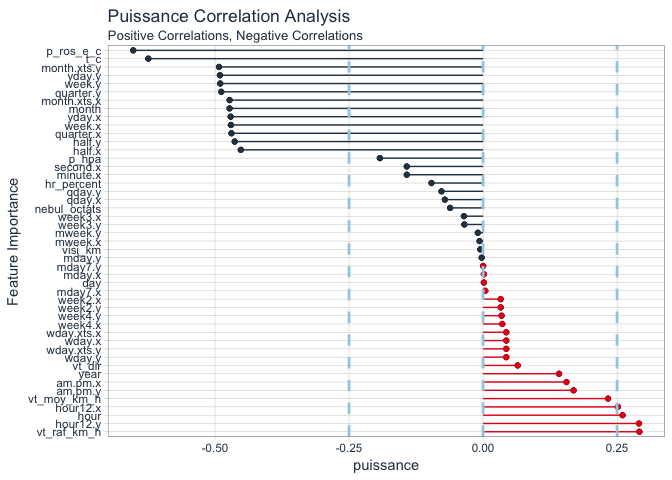

```r
# Feature correlations to puissance
corrr_analysis <- train_data_tbl %>%
  purrr::keep(is.numeric)%>%
  correlate() %>%
  focus(puissance) %>%
  rename(feature = rowname) %>%
  arrange(abs(puissance)) %>%
  mutate(feature = as_factor(feature))

# Correlation visualization
corrr_analysis %>%
  ggplot(aes(x = puissance, y = fct_reorder(feature, desc(puissance)))) +
  geom_point() +
  # Positive Correlations - Contribute to puissance
  geom_segment(aes(xend = 0, yend = feature),
               color = palette_light()[[2]],
               data = corrr_analysis %>% filter(puissance > 0)) +
  geom_point(color = palette_light()[[2]],
             data = corrr_analysis %>% filter(puissance > 0)) +
  # Negative Correlations - Prevent puissance
  geom_segment(aes(xend = 0, yend = feature),
               color = palette_light()[[1]],
               data = corrr_analysis %>% filter(puissance < 0)) +
  geom_point(color = palette_light()[[1]],
             data = corrr_analysis %>% filter(puissance < 0)) +
  # Vertical lines
  geom_vline(xintercept = 0, color = palette_light()[[5]], size = 1, linetype = 2) +
  geom_vline(xintercept = -0.25, color = palette_light()[[5]], size = 1, linetype = 2) +
  geom_vline(xintercept = 0.25, color = palette_light()[[5]], size = 1, linetype = 2) +
  # Aesthetics
  theme_tq() +
  labs(title = "Puissance Correlation Analysis",
       subtitle = "Positive Correlations, Negative Correlations",
       y = "Feature Importance")
```

# Modeling

```r
# Split into training, validation and test sets
train_tbl <- train_data_tbl %>% filter(date < "2016-08-10 00:59:59") %>% select(-c(date,date_utc))
valid_tbl <- train_data_tbl %>% filter(date > "2016-08-10 00:59:59") %>% select(-c(date,date_utc))
test_tbl <- test_data_tbl %>% select(-c(date,date_utc))

# Convert to H2OFrame objects
train_h2o <- as.h2o(train_tbl)
valid_h2o <- as.h2o(valid_tbl)
test_h2o  <- as.h2o(test_tbl)
```

For modeling purposes, we make use of the Automated Machine Learning Functionality of [H2o](https://www.h2o.ai) AutoML which trains and cross-validates a Random Forest, an Extremely-Randomized Forest, a random grid of Gradient Boosting Machines (GBMs), a random grid of Deep Neural Nets, and then trains a Stacked Ensemble using all of the models.

```r
# Sets target and feature names for h2o
y <- "puissance"
x <- setdiff(names(train_h2o), y) # all variable except y

# Run the automated machine learning
models_h2o <- h2o.automl(
  x = x, # predictors
  y = y, # labels
  training_frame    = train_h2o, # training set
  #validation_frame =  valid_h2o, # validation set
  leaderboard_frame = valid_h2o, # validation set
  max_runtime_secs  = 3600, # run-time can be increased/decreased according to your needs 3600 == 1 hour
  seed = 1234
)
lb <- models_h2o@leaderboard
lb # list of top performing models
```

```
##                                     model_id mean_residual_deviance
## 1 GBM_grid_0_AutoML_20180423_091256_model_14               2901.139
## 2 GBM_grid_0_AutoML_20180423_091256_model_46               2961.348
## 3  GBM_grid_0_AutoML_20180423_091256_model_1               3139.124
## 4 GBM_grid_0_AutoML_20180423_091256_model_48               3200.576
## 5  GBM_grid_0_AutoML_20180423_091256_model_0               3334.451
## 6 GBM_grid_0_AutoML_20180423_091256_model_41               3427.990
##       rmse      mae    rmsle
## 1 53.86222 40.54608 0.104513
## 2 54.41827 42.41824 0.104176
## 3 56.02788 43.19962 0.105276
## 4 56.57363 44.12595 0.106370
## 5 57.74471 44.42484 0.107736
## 6 58.54904 45.59821 0.109297
##
## [59 rows x 5 columns]
```

## Summary of Model and Performance Metrics

```r
automl_leader <- models_h2o@leader
automl_leader  # Summary of Model
```

```
## Model Details:
## ==============
##
## H2ORegressionModel: gbm
## Model ID:  GBM_grid_0_AutoML_20180423_091256_model_14
## Model Summary:
##   number_of_trees number_of_internal_trees model_size_in_bytes min_depth
## 1              58                       58               88676         0
##   max_depth mean_depth min_leaves max_leaves mean_leaves
## 1        10    5.17241          1        433   116.82758
##
##
## H2ORegressionMetrics: gbm
## ** Reported on training data. **
##
## MSE:  191.1211
## RMSE:  13.82466
## MAE:  9.813593
## RMSLE:  0.01860669
## Mean Residual Deviance :  191.1211
##
##
## H2ORegressionMetrics: gbm
## ** Reported on validation data. **
##
## MSE:  1836.52
## RMSE:  42.85464
## MAE:  30.58143
## RMSLE:  0.05188275
## Mean Residual Deviance :  1836.52
##
##
## H2ORegressionMetrics: gbm
## ** Reported on cross-validation data. **
## ** 5-fold cross-validation on training data (Metrics computed for combined holdout predictions) **
##
## MSE:  1771.832
## RMSE:  42.09314
## MAE:  30.80154
## RMSLE:  0.05188488
## Mean Residual Deviance :  1771.832
##
##
## Cross-Validation Metrics Summary:
##                               mean           sd  cv_1_valid  cv_2_valid
## mae                      30.801607    0.6334011    30.37733   32.540726
## mean_residual_deviance   1771.8453      70.1181    1689.873   1961.1924
## mse                      1771.8453      70.1181    1689.873   1961.1924
## r2                       0.9763412 0.0011845124   0.9775746   0.9731515
## residual_deviance        1771.8453      70.1181    1689.873   1961.1924
## rmse                     42.077316    0.8199663   41.108067    44.28535
## rmsle                  0.051856548 0.0012124567 0.051846027 0.055083334
##                         cv_3_valid  cv_4_valid  cv_5_valid
## mae                      30.007023   30.684172    30.39878
## mean_residual_deviance   1696.5623   1770.1387   1741.4601
## mse                      1696.5623   1770.1387   1741.4601
## r2                       0.9769415   0.9762926   0.9777457
## residual_deviance        1696.5623   1770.1387   1741.4601
## rmse                     41.189346   42.073017   41.730804
## rmsle                  0.050111033 0.051403906 0.050838437
```

```r
h2o.varimp(automl_leader)[1:20,]  # get variable importance
```

```
## Variable Importances:
##     variable relative_importance scaled_importance percentage
## 1     yday.x    419209504.000000          1.000000   0.689386
## 2       hour     79376808.000000          0.189349   0.130534
## 3     qday.x     33234040.000000          0.079278   0.054653
## 4   hour12.x     20220648.000000          0.048235   0.033253
## 5     week.x     12215657.000000          0.029140   0.020089
## 6        day     10563574.000000          0.025199   0.017372
## 7     wday.x      8227504.500000          0.019626   0.013530
## 8     qday.y      2648376.750000          0.006318   0.004355
## 9    week2.x      2367242.000000          0.005647   0.003893
## 10   week4.x      2066440.500000          0.004929   0.003398
## 11   week3.x      1947040.250000          0.004645   0.003202
## 12  hour12.y      1829398.125000          0.004364   0.003008
## 13     month      1796683.500000          0.004286   0.002955
## 14   mweek.x      1634204.500000          0.003898   0.002687
## 15   mday7.x      1273784.750000          0.003039   0.002095
## 16 p_ros_e_c      1174455.500000          0.002802   0.001931
## 17       t_c      1031906.062500          0.002462   0.001697
## 18    yday.y       825398.812500          0.001969   0.001357
## 19      year       673654.750000          0.001607   0.001108
## 20     p_hpa       638209.375000          0.001522   0.001050
```

# Predictions

```r
##### Prediction #####@
h20_pred <- h2o.predict(automl_leader, test_h2o) # get predictions
conso_prev <- cbind(date = future_dates[,1], as.data.frame(h20_pred))
conso_prev_ts <- timetk::tk_xts(conso_prev)

hc <- highchart(type = "stock") %>%
  hc_title(text = "Charting Predicted Puissance against time") %>%
  hc_subtitle(text = "Consumption Predictions") %>%
  hc_add_series(conso_prev_ts$predict, name = "Puissance")
hc
```

[interactive chart not shown]

## Saving Predictions

```r
write.csv(conso_prev, file = "./datasets/storm.csv",row.names=FALSE) # Team name for the challenge "STORM"
write.csv(conso_prev_ts, file = "./datasets/storm_ts.csv",row.names=FALSE)
```

```r
# All done, shutdown H2O
h2o.shutdown(prompt=FALSE)
```

# Acknowledgement

Special thanks to my former colleagues:

- Benjamin Quemener | Responsable Data Analytics, SNCF
- Sonia Pelloux | Chef de projets Innovation & Recherche, SNCF

for their valuable comments and suggestions.